[figure not shown]

# When a hotspot is first seen by the satellite, can we tell if that fire will stay small, become medium, or grow large?

Group W11_G05** STAT5003: Computational Statistical Methods 23 October 2025

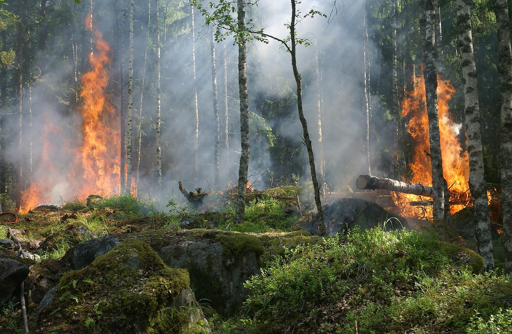

## Agenda

# Part 1: Introduction

## Project Topic

Predicting eventual bushfire size (small/medium/large) from the first VIIRS detection in Australia (2024).

**Why it matters:**

- Early triage → faster response, reduced loss.
- NSW/QLD seasonal pressure → triage is critical.

## Data Sources & Provenance

We use two VIIRS FIRMS datasets for Australia: S-NPP and NOAA-20. They’re mirrored on Kaggle, with the authoritative source being NASA FIRMS (NASA Earthdata).

**S-NPP** contains 979,868 records (rows) and 14 variables (columns).

**NOAA-20** contains 1,059,411 records (rows) and 14 variables (columns).

Combining them improves temporal coverage and reduces missed detections during cloud/smoke gaps.

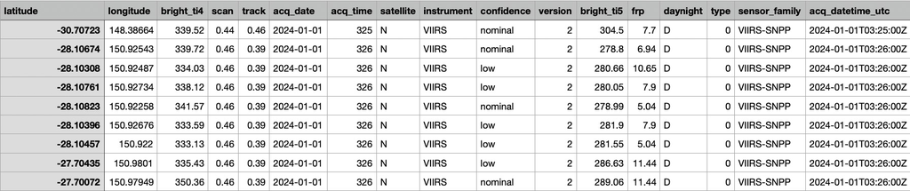

## Spatial & Energy Distribution

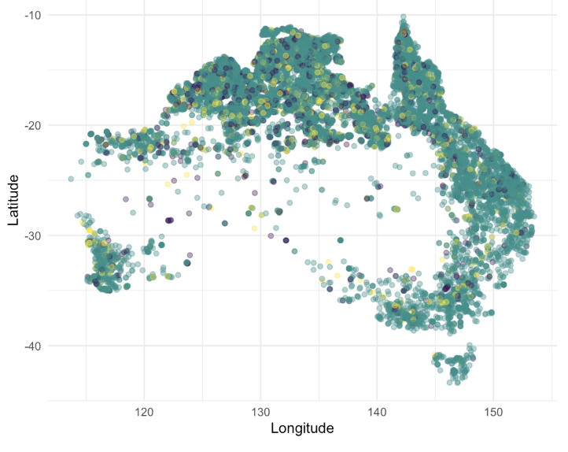

Map: Geographical Distribution of Fire Detections  
(Longitude vs Latitude)

- Fire clusters along eastern/northern Australia
- Sparse detections in desert regions

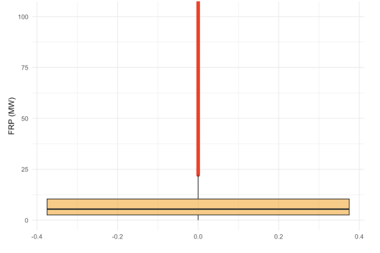

**Boxplot: Fire Radiative Power (FRP)**

- FRP distribution is skewed with extreme high outliers
- Most fires are small to moderate intensity

The spatial and energy characteristics highlight both regional fire clustering and extreme variability in fire intensity.  
These findings emphasize the importance of feature normalization and regional calibration in subsequent modeling stages.

# Part 2: Data Preprocessing

## Aggregation (from points → events)

### Why aggregate?

- Repeated detections of the same fire occur across orbits → point-level counts are inflated.
- Decision-making is at the **event** level (one fire episode), not single pixels.

### How we aggregate (DBSCAN)

- CRS: EPSG:3577 (metres); run spatial DBSCAN with **eps ≈ 1 km**, **minPts = 3**
- Each cluster → `event_id`
- **Inputs:** lon/lat, acq_datetime_utc, FRP
- **Outputs (per event):**
  - `duration_h` = last − first detection (hours)
  - `frp_max` = max FRP
  - `n_hits` = # detections
  - `spread_km²` = area proxy (grid-count)

## Labels & first detection — preparing for classification

### Label (y_size)

- Small: `frp_max < 20` & `duration_h < 12` & `spread_km² < 2`
- Large: `frp_max ≥ 100` or `duration_h ≥ 48` or `spread_km² ≥ 10`
- Medium: otherwise

### Features (first sighting only)

`bright_ti4`, `bright_ti5`, `frp` (*or* `log1p`), `scan`, `track`, `satellite`, `daynight`, `hour`, `month`, `lat_bin`, `lon_bin`  
*(No event metrics as features → no leakage)*

### Pipeline

Multi-class target No leakage Early triage

## What Does Our Data Look Like? — First-detection Modeling Table

### Shape & Coverage

- Rows (events): **[180,372]**
- Columns (features + label): **[14]**
- Time span (UTC): **[2024-01-01] → [2024-12-31]**

### Feature snapshot (first detection)

- Thermal/Energy: `bright_ti4`, `bright_ti5`, `frp` (*or* `log1p(frp)`)
- Sensor/Geometry: `scan`, `track`, `satellite`, `daynight`
- Context: `hour`, `month`, coarse `lat_bin`/`lon_bin`

### Label (target)

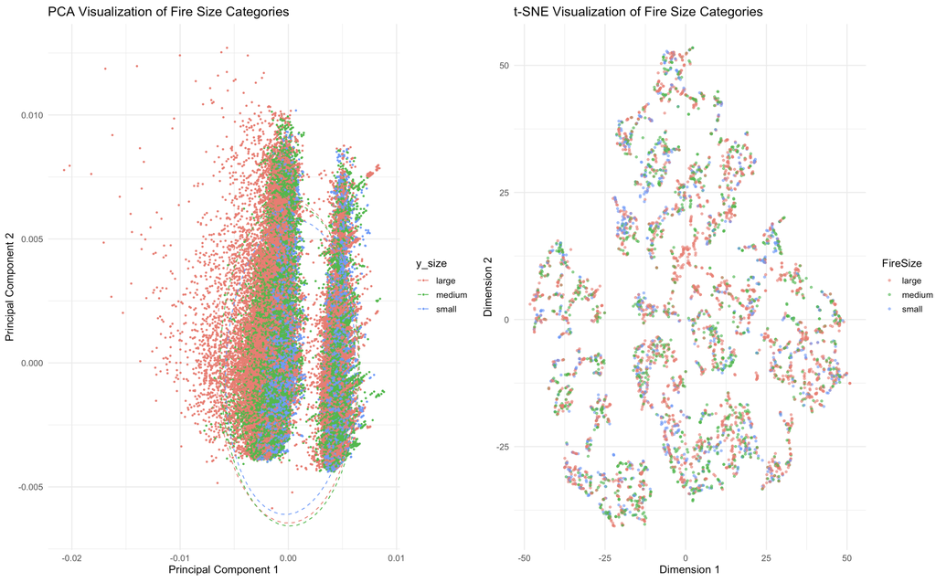

## Data Dictionary

[output not shown]

# Part 3: Modelling

## Model 1: KNN

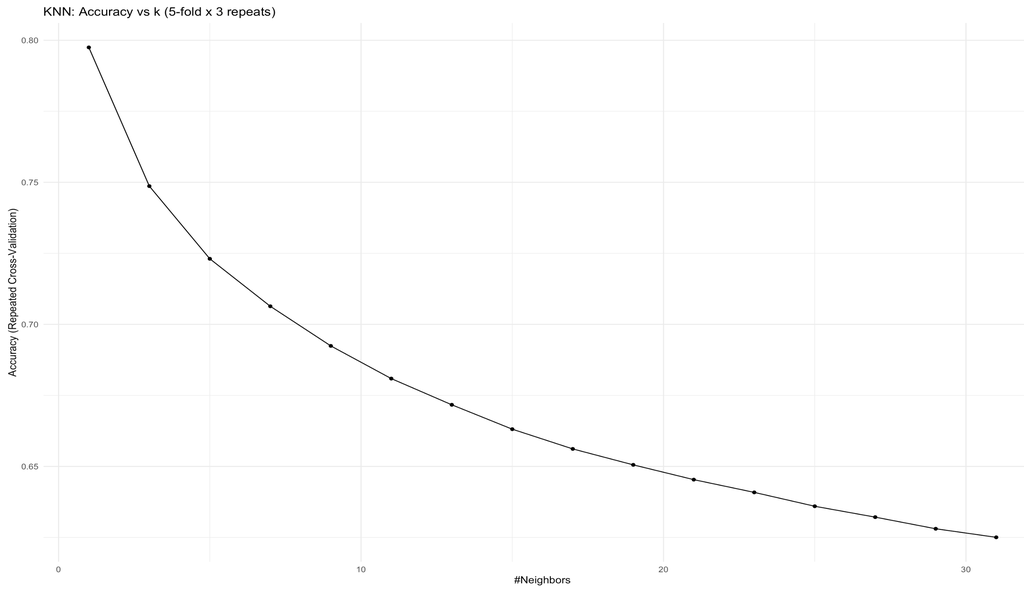

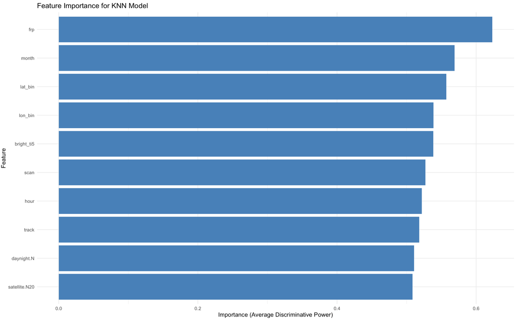

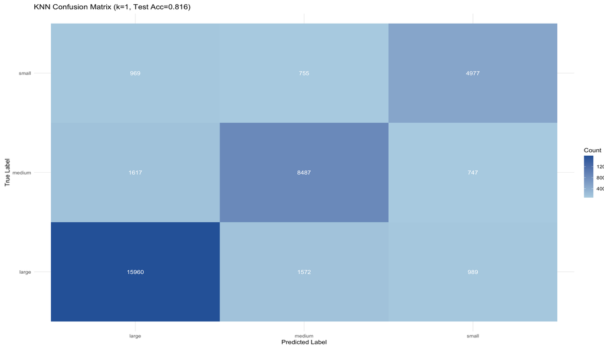

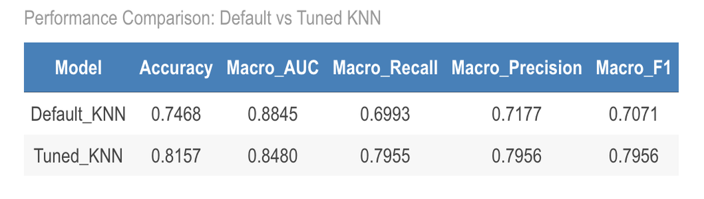

## Model 2: XGBoost

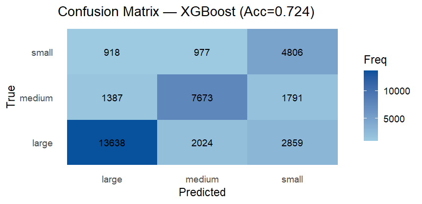

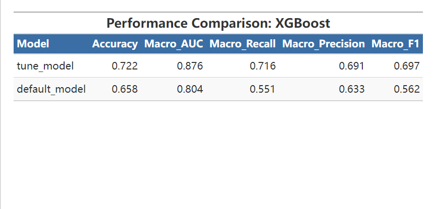

## Model 3: Extra Trees

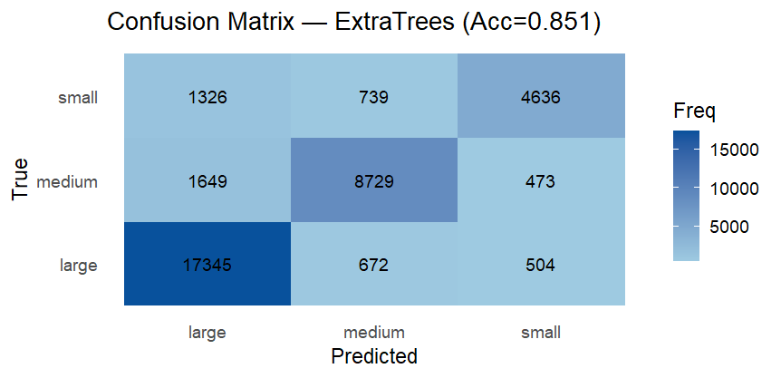

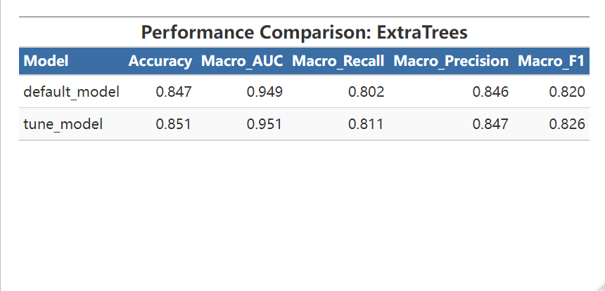

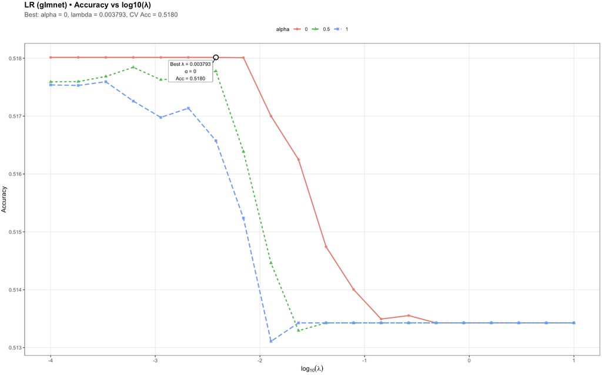

- Interpretability — we can understand how each variable affects the outcome.
- Baseline comparability — it serves as a benchmark model before testing more complex ones.
- Regularization — through the alpha and lambda parameters, we can control overfitting.

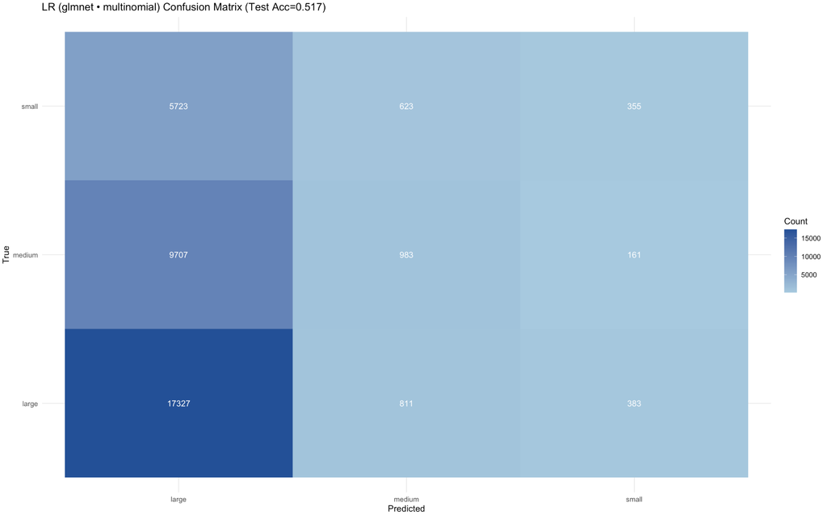

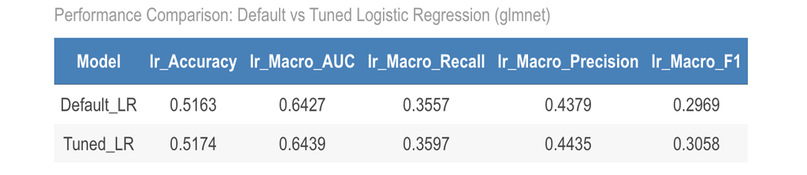

## Model 5: Random Forest

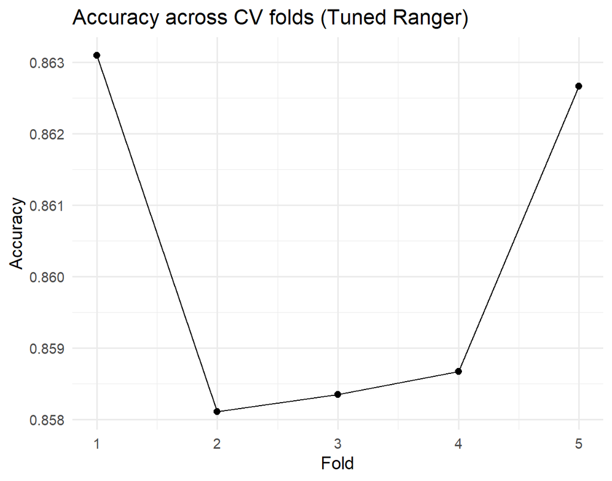

- High predictive power — captures nonlinear relationships and interactions between variables.
- Robustness — resistant to overfitting due to averaging across multiple trees.
- Feature importance — helps identify key drivers behind fire scale differences.

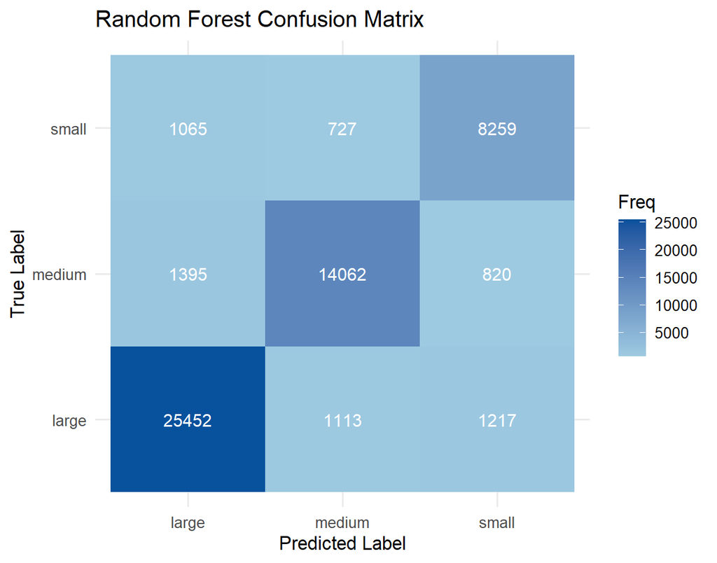

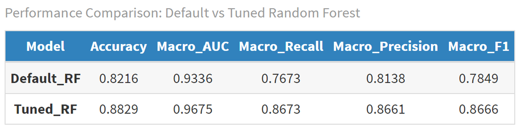

# Part 4: Conclusion

## What we care

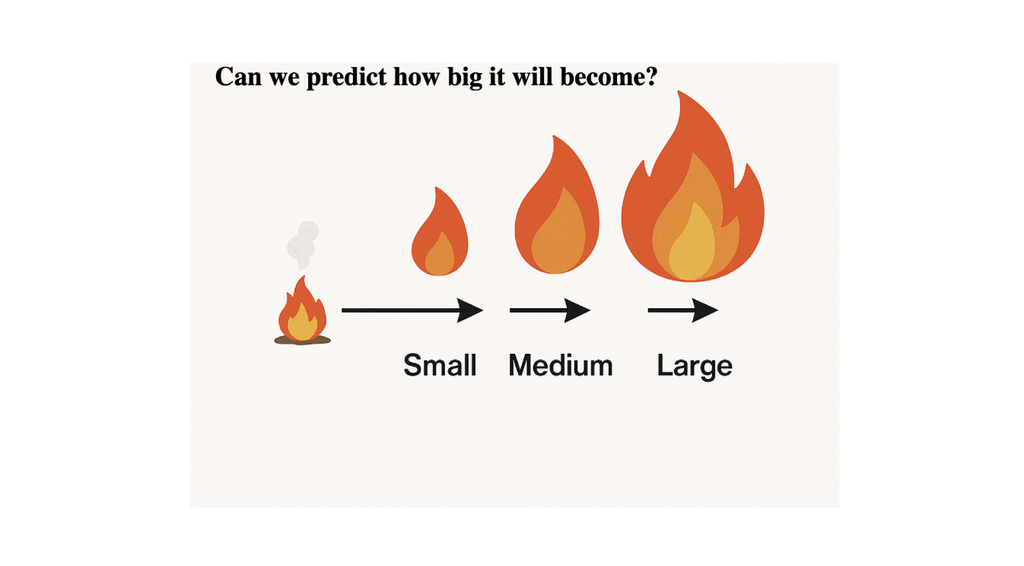

## What we fund

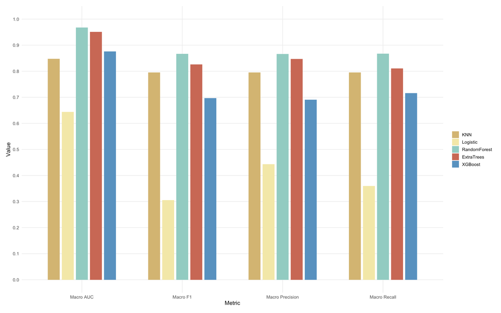

## Why it matters

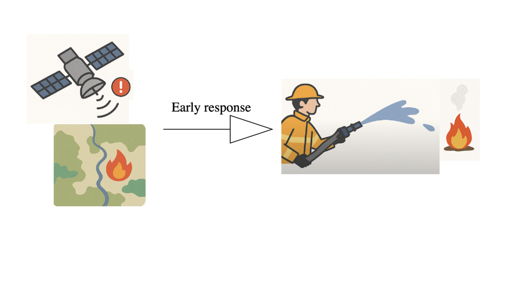

Thanks!

# Part 5: Q&A